# O Solo

Classificação e Propriedades dos Solos Brasileiros  
Bioengenharia de Solos | Aula 1.2

Luiz Diego Vidal Santos

# O Solo

## O Solo

**Disciplina: Cincias do Solos III**

**anejo e Conservação do Solo e da Água**

**Prof. Dr. Luiz Diego Vidal Santos**

| UNIVERSIDADE FEDERAL DE SERGIPE - UFS

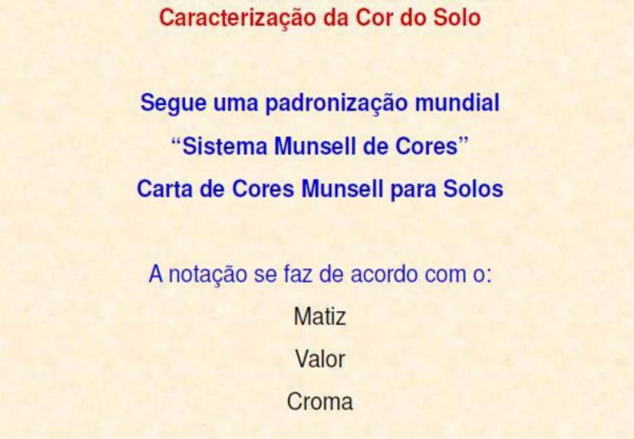

Caracterização do solo em campo

**Note**

Slide original contém 4 imagem(ns) ilustrativa(s).

**CONSERVAÇÃO DO SOLO**

# OS SOLOS SÃO IGUAIS OU DIFERENTES?

# O SOLO

## Horizontes do Solo

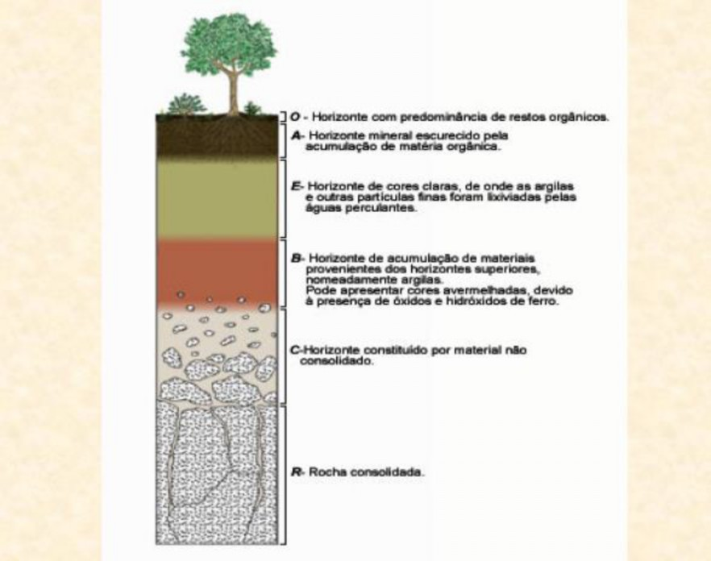

Esquema dos horizontes do solo

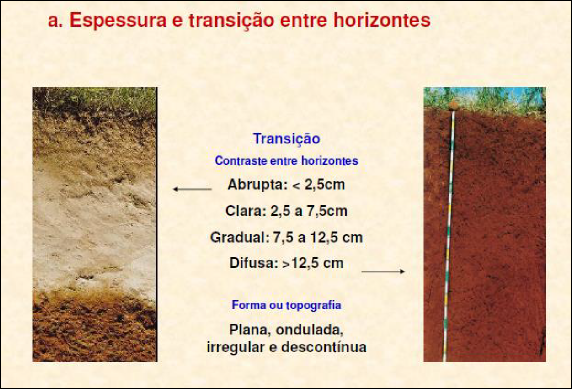

Espessura e transição dos horizontes

## Descrição Morfológica

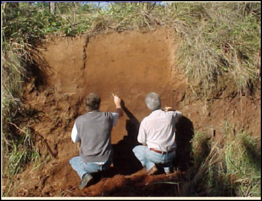

Descrição morfológica do solo

[figure not shown]

Descrição morfológica do solo

## Cores do Solo

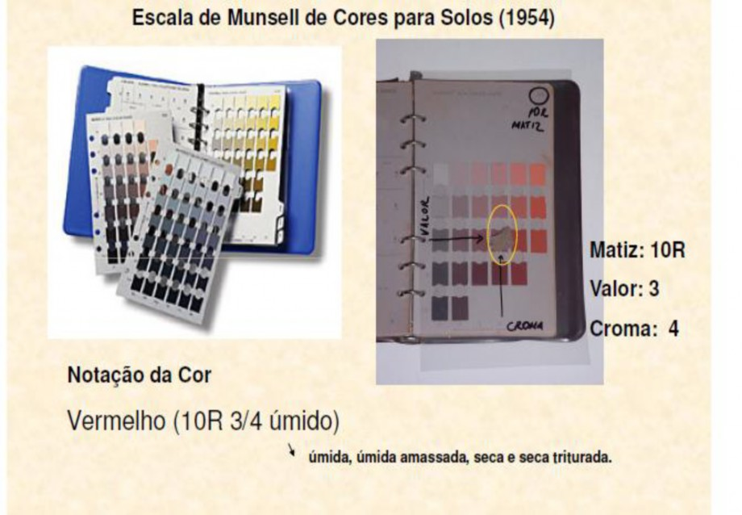

Escala de cores Munsell

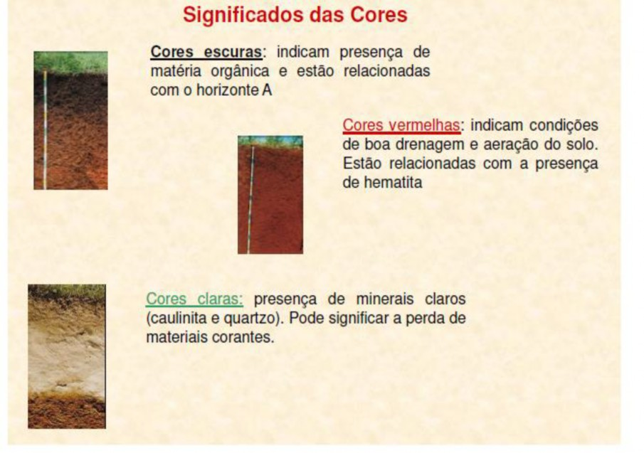

Significado das cores

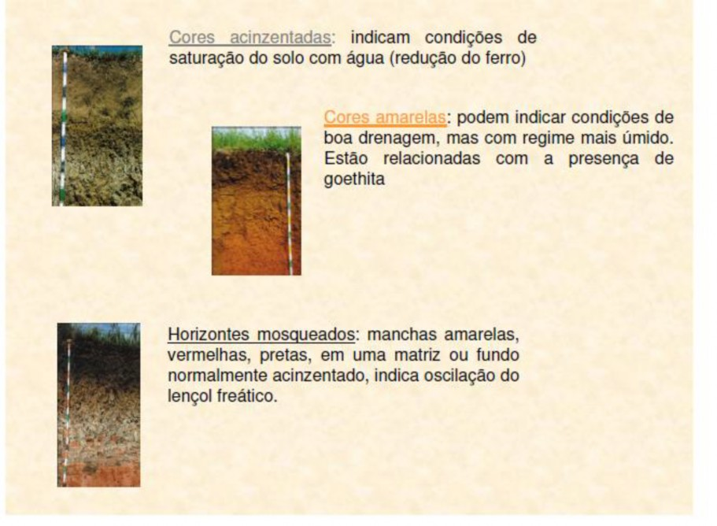

Significado das cores

## Estrutura do Solo

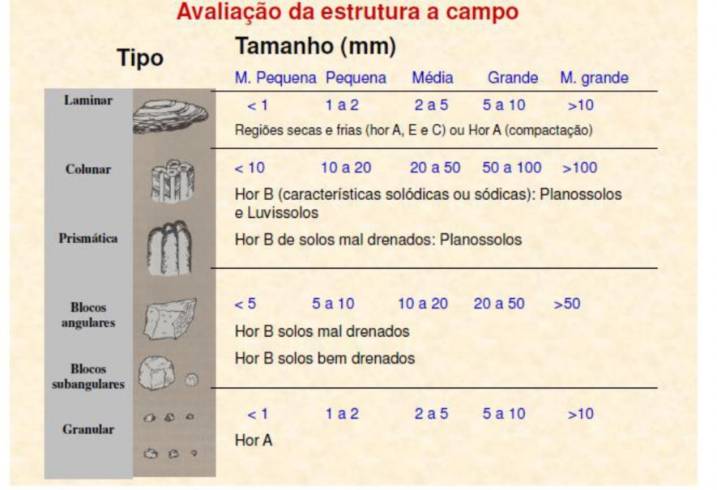

Avaliação da estrutura

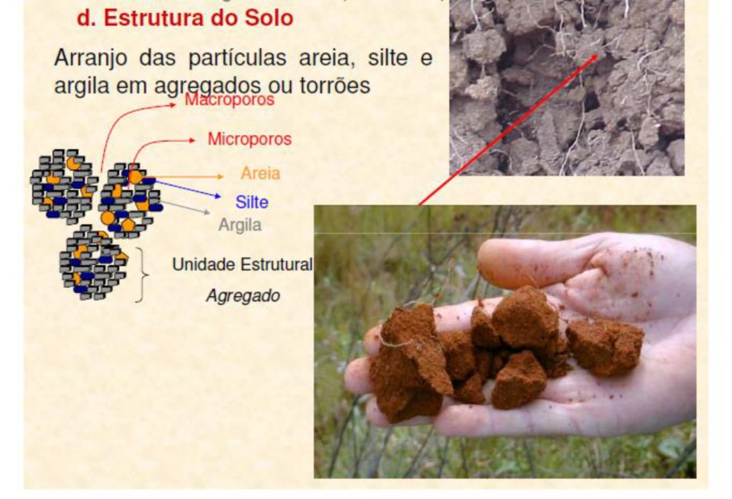

Avaliação da estrutura

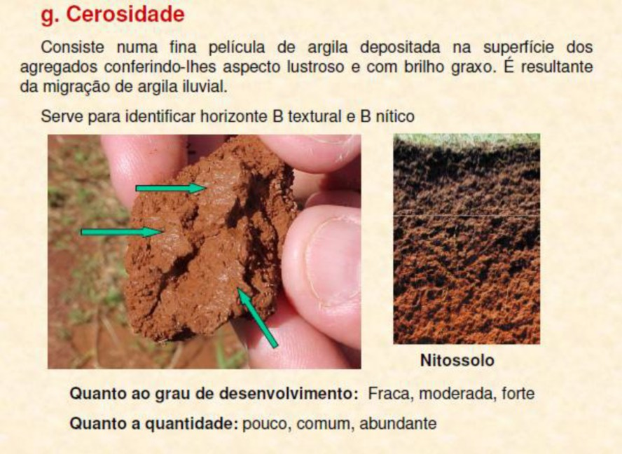

Cerosidade

## Consistência e Porosidade

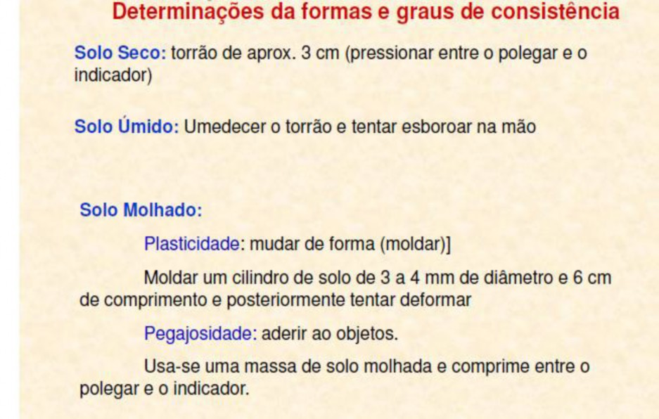

Consistência do solo

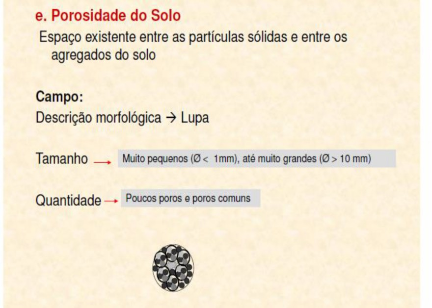

Porosidade do solo

## Classificação Textural

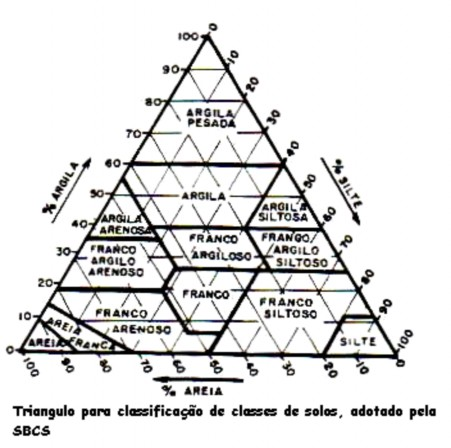

Triângulo de classificação textural

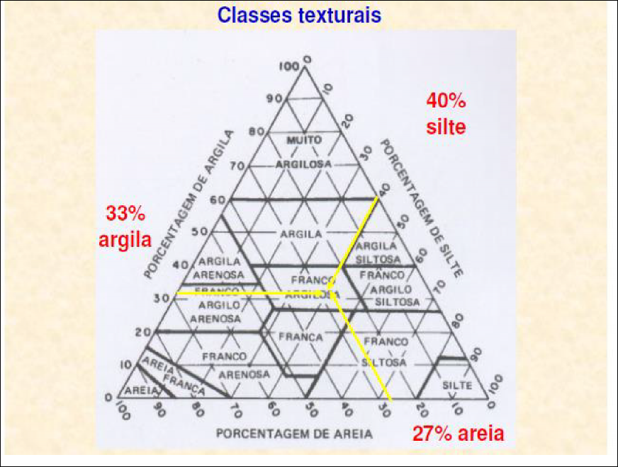

Classes texturais

## Classes de Solo

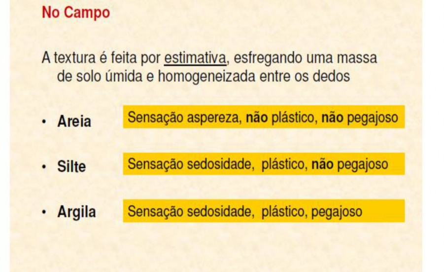

Classificação em campo

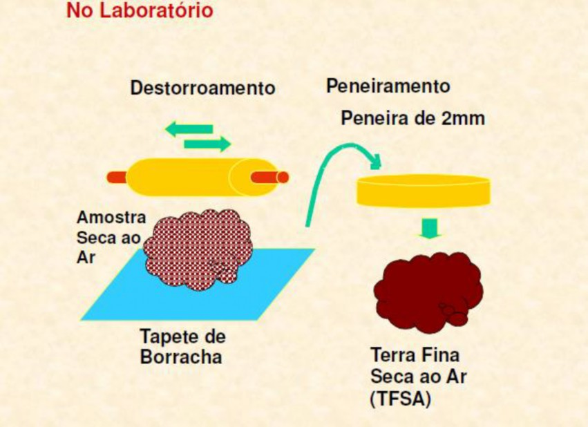

Classificação em laboratório

[figure not shown]

Hierarquia do Sistema Brasileiro

de Classificação de Solos

**Planossolo**

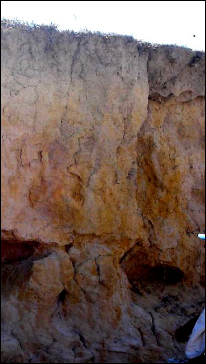

Latossolo Amarelo

**LATOSSOLOS**

**São altamente intemperizados e sem incremento de argila em profundidade. As cores variam de brunadas, avermelhadas ou amareladas, sendo as últimas de maior expressão. A textura varia de média a muito argilosa e, nos mais oxídicos, pode ocorrer estrutura granular, de tamanho muito pequena a pequena e de grau de desenvolvimento que varia de forte a muito forte.**

**Os minerais predominantes na fração argila são caulinita e óxidos de ferro e alumínio.**

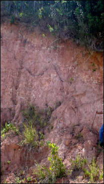

Argissolo Vermelho Amarelo

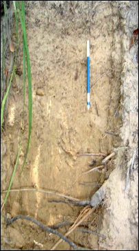

Argissolo Latossólico

**aior teor de argila nos horizontes subsuperfíciais em relação aos superficiais, que caracteriza um gradiente textural ao longo do perfil. A cor pode variar de acinzentada a avermelhada, sendo os matizes amarelos e vermelhos os mais comuns.**

**Os minerais predominantes são argilas de atividade baixa (caulinita) e/ou óxidos.**

**ARGISSOLOS**

**Note**

Slide original contém 1 imagem(ns) ilustrativa(s).

**LUVISSOLOS**

**Possui estrutura bem desenvolvida e alta fertilidade química natural. Identificados pelo aumento significativo dos teores de argila nos horizontes subsuperficias, apresentam, em muitos casos, mudança textural abrupta. De maneira geral são rasos, de coloração avermelhada ou amarelada, com estrutura bem desenvolvida do tipo blocos ou prismas em subsuperfície.**

**A elevada capacidade de troca é decorrente da presença de argilominerais 2:1, com alta saturação por bases devido aos elevados teores de clcio e magnésio**

**São solos pouco evoluídos pedogeneticamente e com ausncia de horizontes diagnósticos subsuperficiais, seja pela reduzida atuação dos processos de pedogenéticos ou ação dos fatores de formação. São jovens, constituídos por material mineral ou por material orgnico com menos de 20 cm de espessura. Apresentam predomínio de características herdadas do material originrio, o qual confere grande variabilidade entre as subordens.**

**Os Neossolos se subdividem em níveis de classificação mais baixos em:**

**NeossolosLitólicos(horizonte superficial diretamente sobre rocha sã ou semidecomposta, ou horizonte C ou Cr);**

**Regolíticos(solos com material superficial assente sobre rocha ou horizonte C ou Cr a mais de 50 cm de profundidade, com ocorrncia de minerais primrios);**

**Flúvicos(derivados de sedimentos aluviais) e**

**Quartzarnicos(solos arenosos, de textura areia ou areia franca).**

**NEOSSOLOS**

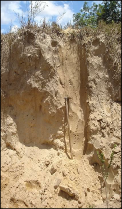

Neossolo Flúvico

**NEOSSOLOS**

**LITÓLICO** | **QUARTZARÊNICO** | **FLÚVICO** | **REGOLÍTICO**

**Note**

Slide original contém 1 imagem(ns) ilustrativa(s).

**NITOSSOLOS**

Apresentam textura argilosa ou muito argilosa, com pouco incremento de argila em profundidade e com estrutura em blocos ou prismas. De maneira geral profundos, com coloração variando de vermelho a bruno, sendo observada pouca diferenciação de cores entre os horizontes (ausncia de policromia).

São normalmente profundos, bem drenados, estruturados, moderadamente cidos e de fertilidade natural muito varivel.

**Note**

Slide original contém 1 imagem(ns) ilustrativa(s).

**CABISSOLOS**

**Compreendem solos com desenvolvimento incipiente, caracterizados pela pouca diferenciação dos horizontes nas características morfológicas, principalmente pela cor e estrutura.**

**A grande variabilidade da natureza e transformação do material de origem proporciona ampla variação em sua composição química e granulométrica.**

**Note**

Slide original contém 2 imagem(ns) ilustrativa(s).

**VERTISSOLOS**

**Identificados pelo baixo grau de desenvolvimento pedogenético e altos teores de argila. Podem apresentar argilominerais 2:1, a qual confere alta capacidade troca catiônica e, expansão e contração, com expressiva movimentação da massa do solo.**

**Comumente observam-se fendas largas e profundas e, estrutura cuneiforme, formadas no período seco, assim como, pode ser verificado superfícies de fricção e micro relevo em superfície denominado de gilgai.**

**São de coloração acinzentada ou preta, sem diferença significativa no teor de argila entre a parte superficial e a subsuperficial do solo. São de elevada fertilidade química**

**Note**

Slide original contém 2 imagem(ns) ilustrativa(s).

**CHERNOSSOLOS**

**Caracterizados pela presença de horizonte superficial relativamente espesso, escuro, com boa agregação e presença de argilominerais 2:1.**

**uito férteis, apresentam de médios a altos teores de carbono e altos teores de clcio e magnésio, conferindo alta saturação por bases. Podem apresentar alto teor de carbonato de clcio secundrio na forma nódulos.**

**Note**

Slide original contém 1 imagem(ns) ilustrativa(s).

**ESPODOSSOLOS**

**Apresentam horizonte subsuperficial com acúmulo de matéria orgnica e alumínio, podendo ou não apresentar acúmulo de ferro. De maneira geral a composição granulométrica tem o predomínio da fração areia. São solos muito pobres e cidos.**

**O horizonte subsuperficial (B espódico) pode apresentar cor escura, acinzentada e muitas vezes amarelada e avermelhada, sendo de maneira geral sobreposto por um horizonte eluvial e de cor clara (horizonte E).**

**Note**

Slide original contém 1 imagem(ns) ilustrativa(s).

**Caracterizados por apresentar drenagem imperfeita e ciclos de redução e oxidação do ferro, levando a segregação do ferro e a formação da plintita (feição destacvel da matriz do solo). A plintita um material brando, que quando submetido a ciclos de umedecimento e secagem pode se consolidar irreversivelmente formando a petroplintita (concreção).**

**As cores predominantemente cinzentas, vermelhas e amareladas no padrão variegado ou mosqueado e muitas vezes com moderado aumento de argila em subsuperfície.**

**PLINTOSSOLOS**

**Note**

Slide original contém 2 imagem(ns) ilustrativa(s).

**GLEISSOLOS**

**aterial predominantemente argiloso e muito argiloso que passou por processos de oxidação e redução em ambiente saturado por gua, mal ou muito mal drenados (hidromórficos). Geralmente estão associados à proximidades de cursos d’gua.**

**As cores predominantes em subsuperfície são acinzentadas ou variegadas, devido aos processos de oxidação e redução do ferro, podendo apresentar mosqueados ou plintita.**

**Note**

Slide original contém 2 imagem(ns) ilustrativa(s).

**ORGANOSSOLOS**

**Formados por elevados teores de matéria orgnica, oriunda da deposição e acúmulo de resíduos vegetais, com ou sem mistura de materiais minerais. O acúmulo de material orgnico pode ocorrer em condições de drenagem livre, em altitude elevada e com baixas temperaturas, ou com forte restrição de drenagem, como nas baixadas ou depressões.**

**Possui elevados teores de carbono e coloração preta, cinzenta muito escura ou brunada, resultantes de acumulação de restos vegetais.**

**Note**

Slide original contém 1 imagem(ns) ilustrativa(s).

**PLANOSSOLOS**

**Apresentam textura predominantemente arenosa em superfície, com grande aumento de argila em subsuperfície e mudança textural abrupta ou transição abrupta com gradiente textural. São adensados em subsuperfície e extremamemto duros quando secos e frequentemente com estrutura prismtica ou colunar em subsperfície.**

**A baixa permeabilidade em subsuperfície condiciona ciclos de redução e oxidação do ferro, propiciando as cores acinzentadas ou variegadas e mosqueados. De maneira geral observa-se um horizonte eluvial e de cor clara sobrepondo o horizonte subsuperficial.**

# O SOLO

Obrigado!

Luiz Diego Vidal Santos